# Anova

## R Markdown

- 1. [Jain, 16.1mod] O desempenho de um sistema que está sendo projetado depende dos três fatores que seguem:
1. Processador: Xeon, SPARC T5, POWER8
2. Sistema operacional: Windows, Linux, NetBSD
3. Tipo de armazenamento: disco rígido, SSD Quantos experimentos são necessários para analisar o desempenho do sistema se
1. Existe interação significativa entre os fatores; = 18 = 3 ( Xeon, SPARC T5, POWER8) * 3 (Windows, Linux, NetBSD) * 2 (disco rígido, SSD)
2. Não existe interação entre os fatores. = 6
- 2. [Jain, 18.1] A tabela abaixo lista os tempos de CPU medidos para dois processadores com duas cargas de trabalho. Cada experimento foi repetido três vezes. Analise o experimento, identificando os fatores estatisticamente significativos e o percentual de variação explicada pelo fator dominante.

```r
dados <- read.table("q2.dat", head=T, colClasses=c("factor", "factor", "numeric"))
dados
```

```
##    carga proc tempo
## 1      I    A 41.16
## 2      I    A 39.02
## 3      I    A 42.56
## 4      I    B 63.17
## 5      I    B 59.25
## 6      I    B 64.23
## 7      J    A 51.50
## 8      J    A 52.50
## 9      J    A 50.50
## 10     J    B 48.08
## 11     J    B 48.98
## 12     J    B 47.10
```

```r
str(dados) # Colunas tem de sempre ser factor
```

```
## 'data.frame':    12 obs. of  3 variables:
##  $ carga: Factor w/ 2 levels "I","J": 1 1 1 1 1 1 2 2 2 2 ...
##  $ proc : Factor w/ 2 levels "A","B": 1 1 1 2 2 2 1 1 1 2 ...
##  $ tempo: num  41.2 39 42.6 63.2 59.2 ...
```

```r
(dados.aov <- aov(tempo ~ carga * proc, data=dados))
```

```
## Call:
##    aov(formula = tempo ~ carga * proc, data = dados)
##
## Terms:
##                    carga     proc carga:proc Residuals
## Sum of Squares    9.5944 239.1454   459.4219   23.8888
## Deg. of Freedom        1        1          1         8
##
## Residual standard error: 1.728034
## Estimated effects may be unbalanced
```

```r
summary(dados.aov)
```

```
##             Df Sum Sq Mean Sq F value   Pr(>F)
## carga        1    9.6     9.6   3.213    0.111
## proc         1  239.1   239.1  80.086 1.93e-05 ***
## carga:proc   1  459.4   459.4 153.853 1.67e-06 ***
## Residuals    8   23.9     3.0
## ---
## Signif. codes:  0 '***' 0.001 '**' 0.01 '*' 0.05 '.' 0.1 ' ' 1
```

```r
(SS <- anova(dados.aov)['Sum Sq'])
```

```
##            Sum Sq
## carga        9.59
## proc       239.15
## carga:proc 459.42
## Residuals   23.89
```

```r
(SST <- sum(SS))
```

```
## [1] 732.0505
```

```r
 100*SS/sum(SS)
```

```
##               Sum Sq
## carga       1.310621
## proc       32.667884
## carga:proc 62.758222
## Residuals   3.263272
```

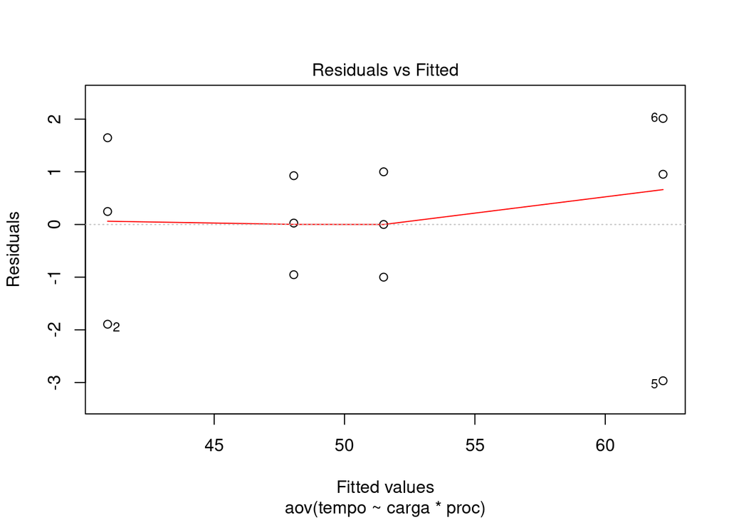

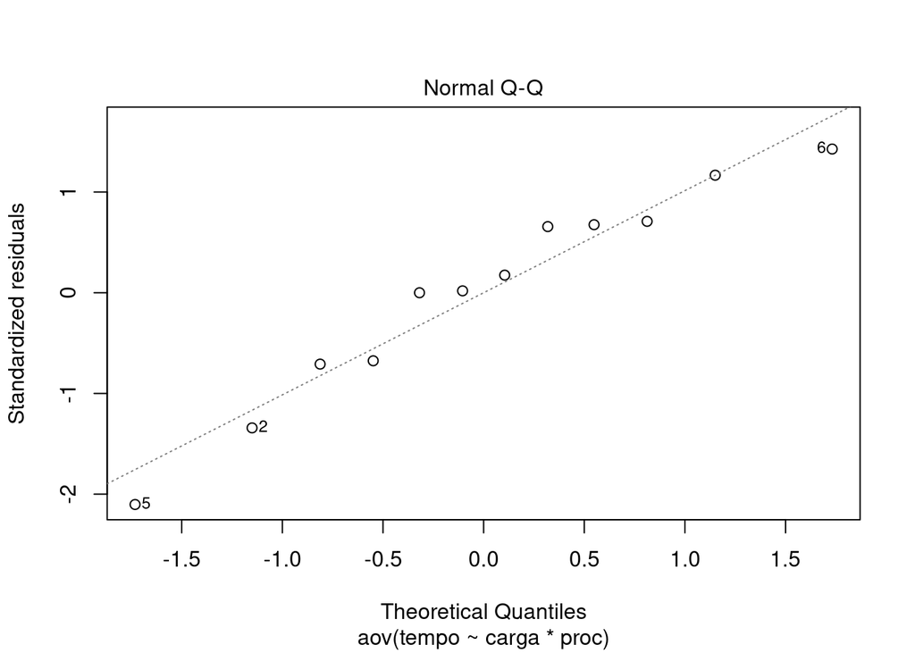

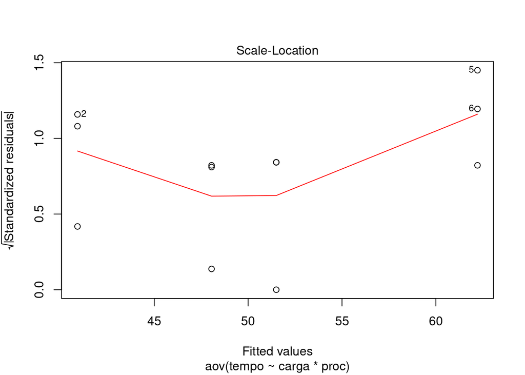

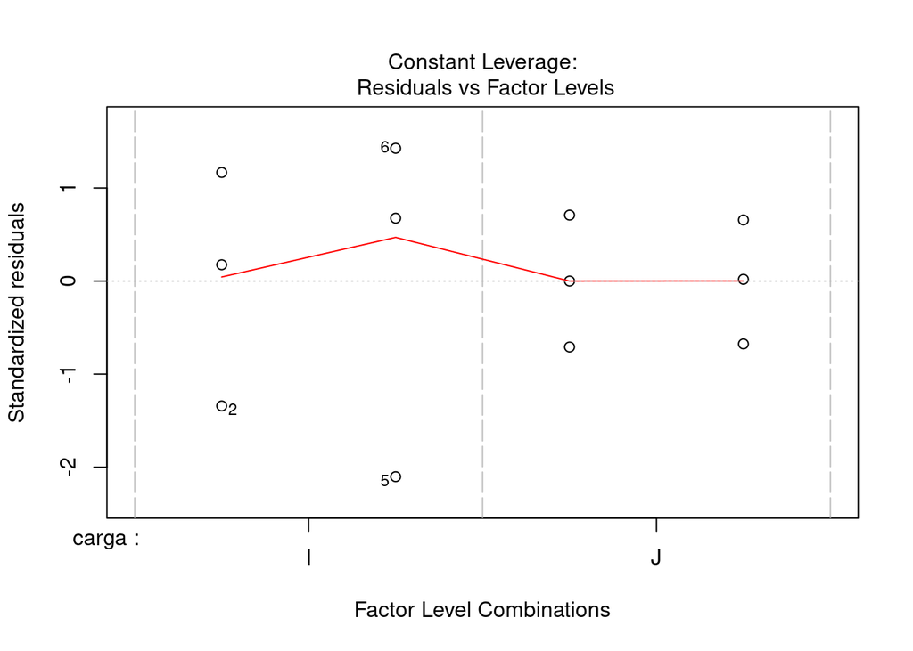

```r
plot(dados.aov)
```

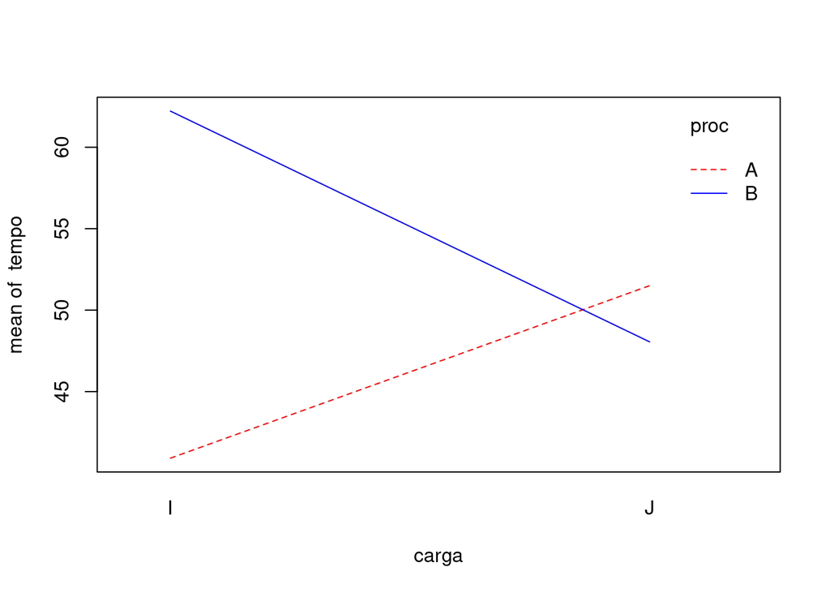

```r
with(dados, interaction.plot(carga, proc, tempo, col=c("red", "blue")))
```

```r
fligner.test(tempo ~ interaction(carga, proc), dados) # p-value > alfa
```

```
##
##  Fligner-Killeen test of homogeneity of variances
##
## data:  tempo by interaction(carga, proc)
## Fligner-Killeen:med chi-squared = 2.4766, df = 3, p-value = 0.4795
```

```r
TukeyHSD(dados.aov) # carga nao eh significativo p adj > alfa
```

```
##   Tukey multiple comparisons of means
##     95% family-wise confidence level
##
## Fit: aov(formula = tempo ~ carga * proc, data = dados)
##
## $carga
##          diff       lwr       upr     p adj
## J-I -1.788333 -4.088989 0.5123224 0.1108172
##
## $proc
##         diff      lwr      upr    p adj
## B-A 8.928333 6.627678 11.22899 1.93e-05
##
## $`carga:proc`
##               diff        lwr       upr     p adj
## J:A-I:A  10.586667   6.068361 15.104972 0.0003168
## I:B-I:A  21.303333  16.785028 25.821639 0.0000018
## J:B-I:A   7.140000   2.621694 11.658306 0.0042968
## I:B-J:A  10.716667   6.198361 15.234972 0.0002907
## J:B-J:A  -3.446667  -7.964972  1.071639 0.1455208
## J:B-I:B -14.163333 -18.681639 -9.645028 0.0000384
```

- R: O fator carga não é significativo, mas os fatores ‘proc’ e ‘carga:proc’ são significativos, a relação entre carga:proc responde por 62,8% da variação observada.
3. [Jain, 22.1mod] Os tempos de CPU medidos com três processadores A1, A2 e A3 e cinco cargas de trabalho B1–B5 estão mostrados na tabela abaixo. Foram realizadas três replicações de cada experimento. Analise os dados e responda:

```r
dados <- read.table("q3.dat", head=T)
str(dados)
```

```
## 'data.frame':    44 obs. of  3 variables:
##  $ carga: Factor w/ 5 levels "B1","B2","B3",..: 1 1 1 1 1 1 1 1 1 2 ...
##  $ proc : Factor w/ 3 levels "A1","A2","A3": 1 1 1 2 2 2 3 3 3 1 ...
##  $ tempo: int  3200 3150 3250 5120 5100 5140 8960 8900 8840 4700 ...
```

```r
#dados
(dados.aov <- aov(tempo ~ carga * proc, data=dados))
```

```
## Call:
##    aov(formula = tempo ~ carga * proc, data = dados)
##
## Terms:
##                      carga       proc carga:proc  Residuals
## Sum of Squares   546976716 1211027744  389771856     126300
## Deg. of Freedom          4          2          8         29
##
## Residual standard error: 65.99373
## Estimated effects may be unbalanced
```

```r
summary(dados.aov)
```

```
##             Df    Sum Sq   Mean Sq F value Pr(>F)
## carga        4 5.470e+08 136744179   31398 <2e-16 ***
## proc         2 1.211e+09 605513872  139033 <2e-16 ***
## carga:proc   8 3.898e+08  48721482   11187 <2e-16 ***
## Residuals   29 1.263e+05      4355
## ---
## Signif. codes:  0 '***' 0.001 '**' 0.01 '*' 0.05 '.' 0.1 ' ' 1
```

```r
(SS <- anova(dados.aov)['Sum Sq'])
```

```
##                Sum Sq
## carga       546976716
## proc       1211027744
## carga:proc  389771856
## Residuals      126300
```

```r
(SST <- sum(SS))
```

```
## [1] 2147902616
```

```r
(SST.percentage = 100*SS/sum(SS))
```

```
##                  Sum Sq
## carga      25.465619896
## proc       56.381873867
## carga:proc 18.146626082
## Residuals   0.005880155
```

```r
# fator dominante é o processador, pois a porcentagem da concentração de variação é maior

model.tables(dados.aov)
```

```
## Tables of effects
##
##  carga
##        B1   B2    B3   B4   B5
##     -3597 1943 -4430 1713 4918
## rep     9    9     9    9    8
##
##  proc
##        A1    A2   A3
##     -4846 -2140 7486
## rep    15    15   14
##
##  carga:proc
##      proc
## carga A1    A2    A3
##   B1   2490  1704 -4194
##   rep     3     3     3
##   B2  -1550   444  1106
##   rep     3     3     3
##   B3   3324  1578 -4901
##   rep     3     3     3
##   B4   -920 -3116  4036
##   rep     3     3     3
##   B5  -3344  -610  5931
##   rep     3     3     2
```

```r
model.tables(dados.aov, type="means")
```

```
## Tables of means
## Grand mean
##
## 9337.045
##
##  carga
##       B1    B2   B3    B4    B5
##     5740 11280 4907 11050 14255
## rep    9     9    9     9     8
##
##  proc
##       A1   A2    A3
##     4491 7197 16823
## rep   15   15    14
##
##  carga:proc
##      proc
## carga A1    A2    A3
##   B1   3200  5120  8900
##   rep     3     3     3
##   B2   4700  9400 19740
##   rep     3     3     3
##   B3   3200  4160  7360
##   rep     3     3     3
##   B4   5100  5610 22440
##   rep     3     3     3
##   B5   6800 12240 28460
##   rep     3     3     2
```

```r
TukeyHSD(dados.aov)
```

```
##   Tukey multiple comparisons of means
##     95% family-wise confidence level
##
## Fit: aov(formula = tempo ~ carga * proc, data = dados)
##
## $carga
##             diff        lwr        upr p adj
## B2-B1  5540.0000  5449.5696  5630.4304 0e+00
## B3-B1  -833.3333  -923.7637  -742.9030 0e+00
## B4-B1  5310.0000  5219.5696  5400.4304 0e+00
## B5-B1  8515.0000  8421.7865  8608.2135 0e+00
## B3-B2 -6373.3333 -6463.7637 -6282.9030 0e+00
## B4-B2  -230.0000  -320.4304  -139.5696 4e-07
## B5-B2  2975.0000  2881.7865  3068.2135 0e+00
## B4-B3  6143.3333  6052.9030  6233.7637 0e+00
## B5-B3  9348.3333  9255.1198  9441.5468 0e+00
## B5-B4  3205.0000  3111.7865  3298.2135 0e+00
##
## $proc
##            diff       lwr       upr p adj
## A2-A1  2706.000  2646.488  2765.512     0
## A3-A1 12332.048 12271.482 12392.613     0
## A3-A2  9626.048  9565.482  9686.613     0
##
## $`carga:proc`
##                      diff        lwr        upr   p adj
## B2:A1-B1:A1  1.500000e+03   1300.878   1699.122 0.0e+00
## B3:A1-B1:A1  1.364242e-11   -199.122    199.122 1.0e+00
## B4:A1-B1:A1  1.900000e+03   1700.878   2099.122 0.0e+00
## B5:A1-B1:A1  3.600000e+03   3400.878   3799.122 0.0e+00
## B1:A2-B1:A1  1.920000e+03   1720.878   2119.122 0.0e+00
## B2:A2-B1:A1  6.200000e+03   6000.878   6399.122 0.0e+00
## B3:A2-B1:A1  9.600000e+02    760.878   1159.122 0.0e+00
## B4:A2-B1:A1  2.410000e+03   2210.878   2609.122 0.0e+00
## B5:A2-B1:A1  9.040000e+03   8840.878   9239.122 0.0e+00
## B1:A3-B1:A1  5.700000e+03   5500.878   5899.122 0.0e+00
## B2:A3-B1:A1  1.654000e+04  16340.878  16739.122 0.0e+00
## B3:A3-B1:A1  4.160000e+03   3960.878   4359.122 0.0e+00
## B4:A3-B1:A1  1.924000e+04  19040.878  19439.122 0.0e+00
## B5:A3-B1:A1  2.526000e+04  25037.375  25482.625 0.0e+00
```

[output cut: 76 more lines]

```
## B1:A3-B5:A2 -3.340000e+03  -3539.122  -3140.878 0.0e+00
## B2:A3-B5:A2  7.500000e+03   7300.878   7699.122 0.0e+00
## B3:A3-B5:A2 -4.880000e+03  -5079.122  -4680.878 0.0e+00
## B4:A3-B5:A2  1.020000e+04  10000.878  10399.122 0.0e+00
## B5:A3-B5:A2  1.622000e+04  15997.375  16442.625 0.0e+00
## B2:A3-B1:A3  1.084000e+04  10640.878  11039.122 0.0e+00
## B3:A3-B1:A3 -1.540000e+03  -1739.122  -1340.878 0.0e+00
## B4:A3-B1:A3  1.354000e+04  13340.878  13739.122 0.0e+00
## B5:A3-B1:A3  1.956000e+04  19337.375  19782.625 0.0e+00
## B3:A3-B2:A3 -1.238000e+04 -12579.122 -12180.878 0.0e+00
## B4:A3-B2:A3  2.700000e+03   2500.878   2899.122 0.0e+00
## B5:A3-B2:A3  8.720000e+03   8497.375   8942.625 0.0e+00
## B4:A3-B3:A3  1.508000e+04  14880.878  15279.122 0.0e+00
## B5:A3-B3:A3  2.110000e+04  20877.375  21322.625 0.0e+00
## B5:A3-B4:A3  6.020000e+03   5797.375   6242.625 0.0e+00
```

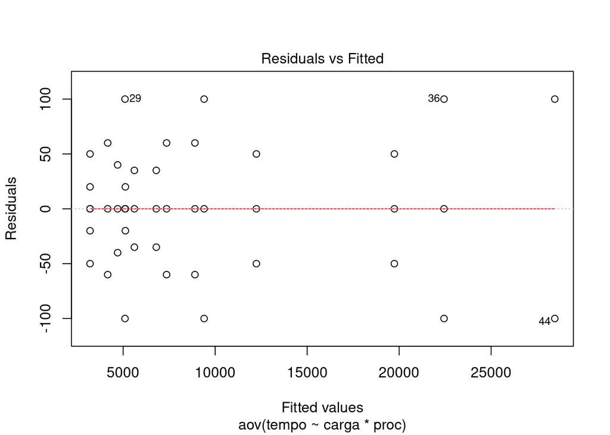

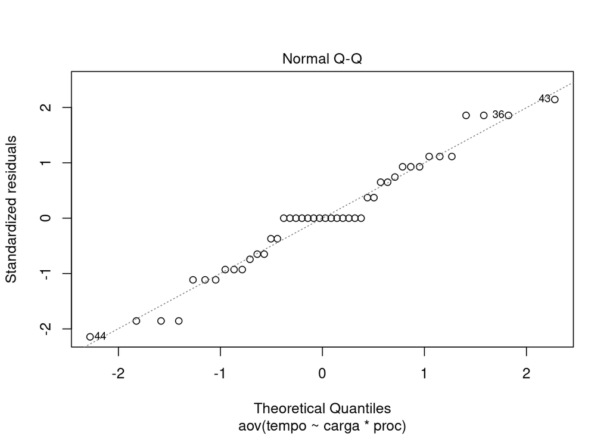

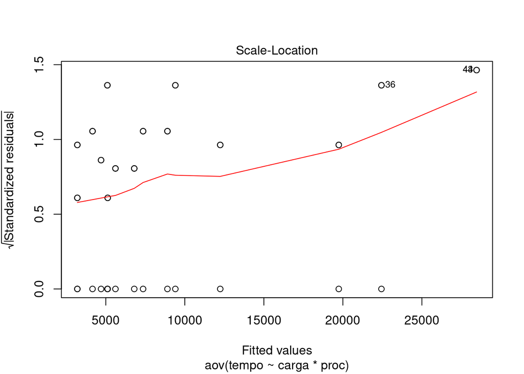

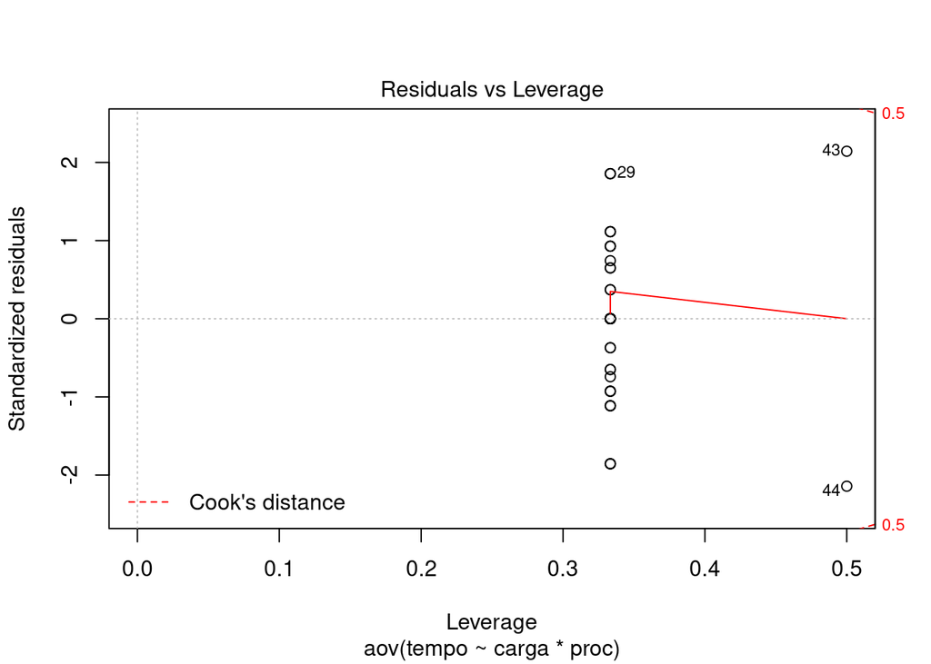

```r
# Não tem diferença significativa qnd o range lwr e upr contém 0
plot(dados.aov)
```

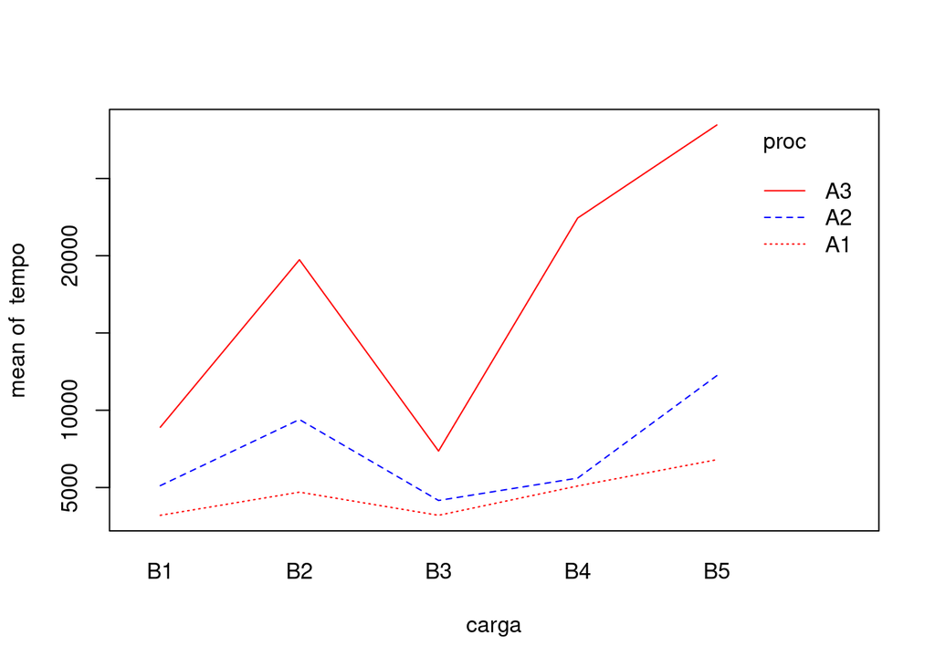

```r
with(dados, interaction.plot(carga, proc, tempo, col=c("red", "blue")))
```